[figure not shown]

[figure not shown]

# Modeling abundance and occupancy using point count data

Michael T. Hallworth  
Smithsonian Conservation Biology Institute  
Migratory Bird Center

Point count data are a cost effective way of surveying large areas to answer ecological questions. For example, point count data can answer the questions:  
- How many species are present in a given area?  
- How many individuals of each species are there?  
- How has the community changed over time?  
- Which habitats is X species associated with?

These are just a few of the possible questions that can be answered using point count data. However, the question of interest determines how the data should be analyzed. If the question deals with *how many species are present here?* then using occupancy modeling would be a good fit. If the question is something like *How has the population size of Ovenbirds changed over time?*, then modeling abundance is more appropriate.

Regardless of the question - accounting for imperfect detection is important. Failing to account for imperfect detection biases estimates of either species richness or abundance low - unless all species and/or individuals are detected perfectly. This is unlikely given that the study organisms are animals and move, may have been siting on a nest during your visit, preening instead of singing, etc.

### The data

```r
require(RCurl)
# Provide the web address of the data files:

fileURLVWdata <- getURL('https://raw.githubusercontent.com/SCBI-MigBirds/MigBirds/master/data/HBEF_2015_simulated.csv')
```

```r
options(width = 100)
# read in Point-count data #
VWdata<-read.csv(text = fileURLVWdata,sep=",")

# view the column names #
names(VWdata)
```

```
##  [1] "Transect"        "Plot"            "Replicate"       "Date"            "Time"
##  [6] "Observer"        "Sky"             "Wind"            "BirdNumber"      "Period"
## [11] "Minute"          "Species"         "Sex"             "DetectionMethod" "Distance"
## [16] "NewRecord"       "CounterSing"
```

```r
# View the first 5 rows of data #
head(VWdata)
```

```
##   Transect Plot Replicate      Date       Time Observer Sky Wind BirdNumber Period Minute Species
## 1      810  314         0 5/22/2015 5:32:00 AM       CH   0    0          1      1      1    REVI
## 2      810  314         0 5/22/2015 5:32:00 AM       CH   0    0          2      1      1    BTBW
## 3      810  314         0 5/22/2015 5:32:00 AM       CH   0    0          3      1      1    BLBW
## 4      810  314         0 5/22/2015 5:32:00 AM       CH   0    0          4      1      1    OVEN
## 5      810  314         0 5/22/2015 5:32:00 AM       CH   0    0          5      1      2    BLBW
## 6      810  314         0 5/22/2015 5:32:00 AM       CH   0    0          6      1      3    BLBW
##   Sex DetectionMethod Distance NewRecord CounterSing
## 1   M               S        1         1           0
## 2   M               S        1         1           0
## 3   M               S        1         1           0
## 4   M               S        1         1           0
## 5   M               S        1         1           0
## 6   M               S        1         1           0
```

Notice that the number of each species is not in the data per se. Each time a species was encountered within the survey it was recorded using it’s alpha code.  
OVEN = Ovenbird  
BTBW = Black-throated blue warbler, etc.

To perform the analyses we need the number of individuals of each species detected within each survey.

#### Exercise:

> From the data you can see above: 1. how many individuals of each species were there?  
> 2. how would/did you determine that?

> Start thinking about what the script might look like to collate those data

Let’s load the packages we will need before we go much further.

```r
# load packages #
# install.packages(c("unmarked","raster","rgeos","chron"),dependencies=TRUE)
library(unmarked)
library(raster)
library(rgeos)
library(chron)
```

#### Brief overview of the subsequent code

The following code will:  
1. Clean up the data (there are little things in all data sets that need to be fixed)  
2. Generate an array of count data for each survey location, period and replicate  
3. Generate an array of observation covariates - Date, Time, Observer  
4. Generate an array of location covariates - Elevation, Slope, Aspect

#### Cleaning the data

Some of the alpha codes have new lines (which show up in the data like “BTBW”) - if they are not fixed before the analysis “BTBW” and “BTBW” will be considered different species. We need to fix this before going any further.

```
##  [1] "BLBW"   "BLBW\n" "BTBW"   "BTBW\n" "BTNW"   "BTNW\n" "OVEN"   "OVEN\n" "REVI"   "REVI\n"
```

```r
# Some of the species codes have new lines for example "BTBW\n"
# this next code removes that & turns "BTBW\n" into "BTBW"
# gsub - looks for a pattern and if found substitutes with a new pattern.
# it's looking for "\n" and replacing "" - nothing.

VWdata$Species<-as.factor(gsub("[\r\n]", "", VWdata$Species))
```

```
## [1] "BLBW" "BTBW" "BTNW" "OVEN" "REVI"
```

Let’s check for another common error in the data:

Lines with out a species entered

```r
# Some rows of the data may have been entered by accident and have no new species - they have blank species #
# remove those rows from the data set #
VWdata<-VWdata[VWdata$Species != "", ]

# Confirm that they were removed by showing the rows that have blank for species #
# should be 0 rows and it is #
VWdata[which(VWdata$Species ==""),]
```

```
##  [1] Transect        Plot            Replicate       Date            Time            Observer
##  [7] Sky             Wind            BirdNumber      Period          Minute          Species
## [13] Sex             DetectionMethod Distance        NewRecord       CounterSing
## <0 rows> (or 0-length row.names)
```

#### Formatting the data

First we need to subset the data to include only the species and individuals counted within a 50m radius.

```r
# Use only the data collected within 50m of the point so no double counting #
VWdata<-VWdata[VWdata$Distance==1,]
```

#### Excercise:

> Is there another way to subset the data to return the same information?

Before we go further it’s helpful to create some useful vectors that we will use later on. * How many counts were conducted  
* How many periods within the count were done

we counted every individual heard/seen in 3 periods within the 10min count. Essentially we do 3 -3:20min point counts within the 10m count period.  
1. 0-3:20 min  
2. 3:20-6:40 min  
3. 6:40-10 min

```r
# Determine the Number of counts
replicate<-min(VWdata$Replicate,na.rm=TRUE):max(VWdata$Replicate,na.rm=TRUE)
```

```
## [1] 0 1 2 3
```

```r
# Determine the number of periods within a count

period<-min(VWdata$Period,na.rm=TRUE):max(VWdata$Period,na.rm=TRUE)
```

```
## [1] 1 2 3
```

```r
# number of sites surveyed #

Sites<-length(unique(VWdata[,2]))

# We also need a vector of sites so we can loop through them later.
# The `as.factor` sets the range between 1 and the number of sites surveyed.
# this is necessary because the plots are not numbered sequentially - as.factor fixes that.

sites<-levels(as.factor(VWdata[,2]))
```

```
## [1] 373
```

```r
# List the species of interest (S.O.I) #
S.O.I <- c("BLBW", "BTBW", "BTNW","OVEN", "REVI")
```

#### Structuring the data into capture histories

Next we generate a capture history for each species - I provide an example for 1 species. In the code below we utilize `for` loops. `for` loops are used for repeated tasks. The fastest way to use `for` loops is to create an object first to store the results of the `for` loop. We do this below.

```r
# Create a Plot x Period x Replicate array of abundance for the species of interest
# this makes an empty 3 dimensional array - Plot x Period x Replicate
# that is filled with NAs

# create an empty array (filled with NA) -
# the number of rows = sites
# the number of columns = periods
# the number of dimensions = replicates

# we will call the array a species matrix or spec.mat for short. We will want to keep track of the species so we
# include the alpha code as well.

spec.mat_OVEN<- array(NA, c(length(sites), length(period),length(replicate)))
rownames(spec.mat_OVEN)<-sites

# This next line makes the spec.mat for each species.

spec.mat_BLBW<-spec.mat_BTBW<-spec.mat_BTNW<-spec.mat_REVI<-spec.mat_OVEN

# Here is how to fill the array with the data that we want #
# Here is an example for the Ovenbird #
# OVEN

temp.sp <- subset(VWdata, Species == S.O.I[4]) # SET S.O.I number to SPECIES OF INTEREST - 4 is OVEN

# for each replicate #
  for(i in replicate){
    # this subsets for each replicate
      temp.rp <- subset(temp.sp, Replicate == i)
# for each period #
   # within each replicate - subset by period
      for (p in period){
           temp.p<- subset(temp.rp,Period==p)
# for each plot #
       for(k in sites){

               temp.st <- subset(temp.p, Plot == k)
               temp.abund <- as.numeric(length(temp.st$Species))
           spec.mat_OVEN[k,p,i+1]<- temp.abund     # HERE YOU NEED TO CHANGE THE spec.mat NAME #

        }  # For plot
    }  # For period
}# For Replicate
```

Let’s take a look at what the resulting array looks like. The `str` function stands for structure and can be used to see what the structure of an object looks like.

```r
# Here you can see that we have 373 rows - 1 for each survey site,
# 3 columns - 1 for each period
# and the 3rd dimenson represents the replicate.

str(spec.mat_OVEN)
```

```
##  num [1:373, 1:3, 1:4] 0 0 0 0 0 0 1 0 0 1 ...
##  - attr(*, "dimnames")=List of 3
##   ..$ : chr [1:373] "1" "2" "3" "4" ...
##   ..$ : NULL
##   ..$ : NULL
```

```r
#let's take a look at the first few rows for replicate 1

head(spec.mat_OVEN[,,1])
```

```
##   [,1] [,2] [,3]
## 1    0    0    0
## 2    0    0    0
## 3    0    0    0
## 4    0    0    0
## 5    0    0    0
## 6    0    0    0
```

There were no Ovenbirds detected on the first few survey points during the first replicate.

#### Covariates

**Site level Covariates**

The next bit of code extracts some potential covariates that we might be interested in from the data set.

First, we will get some of the physical covariates for each site

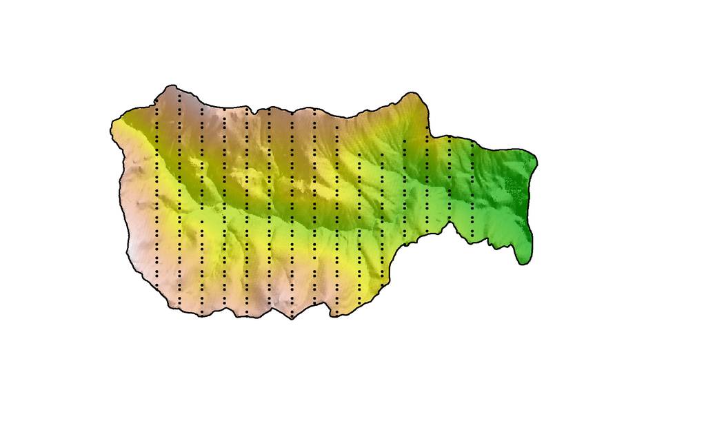

```r
##########################################################################################
#
# Generate the physical covariates for each site
#
##########################################################################################

# Save the projection of the data so we can use it easily later #

UTM19N<-"+proj=utm +zone=19 +ellps=GRS80 +datum=NAD83 +units=m +no_defs"

# Read in HBEF boundary #


HBEF<-shapefile("spatial_layers/HBEFboundary_WGS84.shp")

# Project the shapefile into UTMs

HBEF<-spTransform(HBEF,CRS(UTM19N))

# Read in site locations

SiteLocs<-shapefile("spatial_layers/SchwarzPlots_WGS84.shp")

# keep only the Plots were we actually count #

SiteLocs<-SiteLocs[which(SiteLocs$SCHWARZ_ID %in% sites),]

# Transform the data into UTMs
SiteLocs<-spTransform(SiteLocs,CRS(UTM19N))

# Read in digital elevation model to extract elevation #

DEM<-raster("spatial_layers/hb10mdem.txt")

# Project the data into UTMs
DEM<-projectRaster(DEM,crs=UTM19N)

# Create Slope and Aspect because it might be important #

Aspect<-terrain(DEM,'aspect')

Slope<-terrain(DEM,'slope')
```

#### Extract physical characteristics to each survey site

Often times when modeling either abundance or occupancy - it helps to standardize the covariates in the model. This helps the model converge faster. Below we will make two `data.frames`. One will store the covariate data, the other will store the standardized covariates.

```r
# Make an empty data.frame to store the covariates #
# here we make two data.frames - one to store the Covariates and one to store standardized covariates (siteCovs) #

Covariates<-siteCovs<-data.frame(Elevation=rep(NA,length(sites)),
                                 Aspect=rep(NA,length(sites)),
                                 Slope=rep(NA,length(sites)))

# Assign the site names as row names #
rownames(siteCovs)<-sites
rownames(Covariates)<-sites

# Elevation

Covariates[,1]<-extract(DEM,SiteLocs)
siteCovs[,1]<-(Covariates[,1]-mean(Covariates[,1]))/sd(Covariates[,1])

# Aspect

Covariates[,2]<-extract(Aspect,SiteLocs)
siteCovs[,2]<-(Covariates[,2]-mean(Covariates[,2]))/sd(Covariates[,2])

# Slope

Covariates[,3]<-extract(Slope,SiteLocs)
siteCovs[,3]<-(Covariates[,3]-mean(Covariates[,3]))/sd(Covariates[,3])
```

```
##   Elevation    Aspect     Slope
## 1  818.6771 0.1894923 0.1808273
## 2  856.6822 1.3802499 0.2443474
## 3  842.4990 2.3006748 0.4442618
## 4  846.7539 5.8217979 0.1894956
## 5  866.9452 5.5484515 0.1105238
## 6  894.7712 5.3278027 0.1652264
```

```
##   Elevation     Aspect      Slope
## 1  1.420383 -1.3778381 -0.3325058
## 2  1.676090 -0.7078272  0.2468908
## 3  1.580662 -0.1899259  2.0704039
## 4  1.609290  1.7913263 -0.2534387
## 5  1.745142  1.6375208 -0.9737773
## 6  1.932361  1.5133669 -0.4748091
```

Now that we have the physical site covariates we need to create survey or observation covariates.

#### Survey / Observation Covariates

Here we set up covariates that could influence detection. For example - the time a point count started may influence detection - we may want to include that in our model. Below is code showing how to set up these covariates from the count data.

#### Date

```r
# Format the dates

VWdata$Date2 <- as.Date(VWdata$Date, format="%m/%d/%Y")

# create Day of year (doy) variable - Julian date

Jan1.15 <- as.Date("1/1/2015", format="%m/%d/%Y")

Jan1.15 <- sapply(Jan1.15, as.integer)

VWdata$doy <- sapply(VWdata$Date2, as.integer)

VWdata$doy <- VWdata$doy - Jan1.15

# Create a site x occasion matrix of dates

doy.15 <- matrix(NA, length(sites), length(replicate))
rownames(doy.15) <- sites
colnames(doy.15) <- replicate

for(k in Sites){
  for(i in replicate) {
    temp <- subset(VWdata, Replicate==i & Plot==k)
    temp.DOY <- as.numeric(levels(factor(temp$doy)))
    if (length(temp.DOY)>0){
        doy.15[k,i+1] <- temp.DOY
        }
    } # For replicate
} # For Sites

# Change the matrix from characters to numeric #

doy.15<-structure(as.numeric(doy.15), dim=dim(doy.15), dimnames=dimnames(doy.15))

# All covariates need to be standardized. You can use the function scale() to do that #

doy.15scaled<-scale(doy.15)

# Any missing values can be given the mean very easily after we standardize. The mean is now 0.
# Fill any missing values with the mean.

doy.15scaled[is.na(doy.15scaled)]<-0
```

#### Observer

```r
# looks at the different observers #
levels(factor(VWdata$Observer))
```

```
## [1] "AJS" "CH"  "DJW" "JDW" "MTH"
```

```r
# Create a site x occasion matrix of obs
obs.15 <- matrix(NA, length(sites), 4)
rownames(obs.15) <- sites
for(k in Sites){
for(i in replicate) {
    temp <- subset(VWdata, Replicate==i & Plot==k)
    temp.obs <- temp$Observer
    if(length(temp.obs) > 0) {
        obs.15[k,i+1] <- unique(temp.obs)
        } #If
    } # For Sites
} # For replicate
obs.15[is.na(obs.15)]<-0
```

#### Time of count

```r
# Format the times

VWdata$Time2 <-gsub(" AM", "", VWdata[,5])
head(VWdata$Time2)
```

```
## [1] "5:32:00" "5:32:00" "5:32:00" "5:32:00" "5:32:00" "5:32:00"
```

```r
# Create a site x occasion matrix of times

time.15 <- matrix(NA, length(sites), length(replicate))
rownames(time.15 ) <- sites
colnames(time.15)<-replicate

for(k in Sites){
for(i in replicate){
    temp <- subset(VWdata, Replicate==i & Plot==k)
    temp.time <- temp$Time2
    if(length(temp.time) > 0) {
        time.15[k,i+1] <- unique(temp.time)
        } # If
    } # For Sites
} # For replicate

# Change the matrix from characters to numeric #
times.15<-structure(times(time.15), dim=dim(time.15), dimnames=dimnames(time.15))

# Scale the time covariate #
time<-scale(times.15)

# Fill missing data with the mean - which is 0 after being scaled #
time[is.na(time)]<-0
```

### Running the analysis using unmarked

Now that we have all data structured - we can start the analysis.

A brief overview of the subsequent code:  
* Input the data into an `unmarked` dataframe - necessary for analysis in `unmarked`  
* run the analysis using `unmarked`  
* use the models to predict the number of individuals within 50x50m pixels in HBEF  
* plot the results

We will occupancy first, but our data are structured for abundance. First we need to covert our count data into presence/absence data. That’s fairly easy to do.

```r
# Here we transfer the abundance data to a new array called Oven_occu

Oven_occu<-spec.mat_OVEN

# Here we set all values >1 = 1 - presence/absence data.

Oven_occu[Oven_occu>1]<-1
```

#### Make an `unmarked` frame

```r
# Make an empty list to store the unmarked frames in.
# We first specify the occupancydata, y=Oven_occu[,,replicate]
# we then set the siteCovs as our siteCovs matrix

OVEN<-vector('list',4)
for(i in 1:4){
OVEN[[i]]<-unmarkedFrameOccu(y=Oven_occu[,,i],
                               siteCovs=siteCovs)
}
```

**Run the analysis**

*note* - formula format - ~covariates of detection ~ covariates for occupancy in that order

```r
# formula describing covariates of detection and abundance, in that order
Rep0<-occu(~1 ~Elevation + Aspect + Slope, OVEN[[1]],method="BFGS", se=TRUE, engine="C")

Rep1<-occu(~1 ~Elevation + Aspect + Slope, OVEN[[2]],method="BFGS", se=TRUE, engine="C")

Rep2<-occu(~1 ~Elevation + Aspect + Slope, OVEN[[3]],method="BFGS", se=TRUE, engine="C")

Rep3<-occu(~1 ~Elevation + Aspect + Slope, OVEN[[4]],method="BFGS", se=TRUE, engine="C")
```

```r
Rep0
```

```
##
## Call:
## occu(formula = ~1 ~ Elevation + Aspect + Slope, data = OVEN[[1]],
##     method = "BFGS", se = TRUE, engine = "C")
##
## Occupancy:
##             Estimate    SE      z  P(>|z|)
## (Intercept)   0.0744 0.109  0.680 4.97e-01
## Elevation     0.0864 0.111  0.777 4.37e-01
## Aspect       -0.4548 0.113 -4.032 5.53e-05
## Slope        -0.0772 0.110 -0.700 4.84e-01
##
## Detection:
##  Estimate    SE    z  P(>|z|)
##      0.94 0.102 9.24 2.57e-20
##
## AIC: 1157.08
```

**Predictions**

```r
# structuring data so we can make predictions based on physical attributes

# Read in 50m x 50m grid to make predictions on #

HBEFfishnet<-shapefile("spatial_layers/HBEFfishnet.shp")
HBEFcentroids<-shapefile("spatial_layers/HBEFfishnet_label.shp")

# Calculate standardized Elevation, Aspect and Slope for predictions #

STDelev<-calc(DEM,fun=function(x){(x-mean(Covariates[,1]))/sd(Covariates[,1])})
STDaspect<-calc(Aspect,fun=function(x){(x-mean(Covariates[,2]))/sd(Covariates[,2])})
STDslope<-calc(Slope,fun=function(x){(x-mean(Covariates[,3]))/sd(Covariates[,3])})
```

```r
# Make a data set called NewData with the coordinates, Elevation, Aspect and Slope #
# Note - the variable names need to be EXACTLY the same as the unmarked frame covariate names

NewData<-data.frame(x=HBEFcentroids@coords[,1],
                    y=HBEFcentroids@coords[,2],
                    Elevation=extract(STDelev,HBEFfishnet,fun=mean),
                    Aspect=extract(STDaspect,HBEFfishnet,fun=mean),
                    Slope=extract(STDslope,HBEFfishnet,fun=mean))
```

Now that we have set up a new data set to make predictions we can go ahead and use the output from the analysis to determine occupancy within each 50x50m area of HBEF.

```r
# compute the expected occupancy at each grid cell

## extract the coefficients for the best model - we only ran one model
betaRep0<-coef(Rep0)
```

#### Map the results

There are two ways to map the results-  
1. create rasters of standardize covariates and use raster calculations  
2. make a raster from the predicted occupancy

Raster calculations:

```r
# Make the rasters for the standardize covariates

elevation<-rasterFromXYZ(cbind(NewData[,c(1:2,3)]))
aspect<-rasterFromXYZ(cbind(NewData[,c(1:2,4)]))
slope<-rasterFromXYZ(cbind(NewData[,c(1:2,5)]))

# Raster calculations - the overlay function takes more than two raster layers
# note - psi - occupancy is modeled using the logit scale - to backtransform we can
# use the built in R function - plogis.

# Make a raster of Ovenbird Occupancy #
OVEN0<-overlay(elevation,aspect,slope,fun=function(x,y,z){
               plogis(betaRep0[1]+ # intercept
                      betaRep0[2]*x +  # x is the elevation layer
                      betaRep0[3]*y +  # y is the aspect layer
                      betaRep0[4]*z)})   # z in the slope layer
```

Predctions using the predict function in the `unmarked` package

```r
OccuOven<-predict(Rep0,type="state",newdata=NewData,appendData=TRUE)
```

```r
head(OccuOven)
```

```
##   Predicted         SE     lower     upper        x       y  Elevation    Aspect       Slope
## 1 0.4403802 0.04578773 0.3534826 0.5310917 274857.9 4866056 -0.3980050 0.8017219 -1.10143357
## 2 0.4566658 0.03924921 0.3813529 0.5340134 274907.9 4866056 -0.3729957 0.6123322 -0.81061823
## 3 0.4103024 0.04897520 0.3187675 0.5085019 274957.9 4866056 -0.3442296 1.0850015 -1.11563316
## 4 0.3828978 0.04839852 0.2934421 0.4810569 275007.9 4866056 -0.3196367 1.2999557 -0.87066134
## 5 0.3966794 0.03934738 0.3226635 0.4757483 275057.9 4866056 -0.2732631 1.0355982 -0.01195223
## 6 0.3798557 0.04449619 0.2972599 0.4700507 275107.9 4866056 -0.2250362 1.2840317 -0.50394644
```

Make the map from the predictions

```r
OVEN.occu<-raster::rasterFromXYZ(cbind(OccuOven[,5:6],OccuOven[,1]))
```

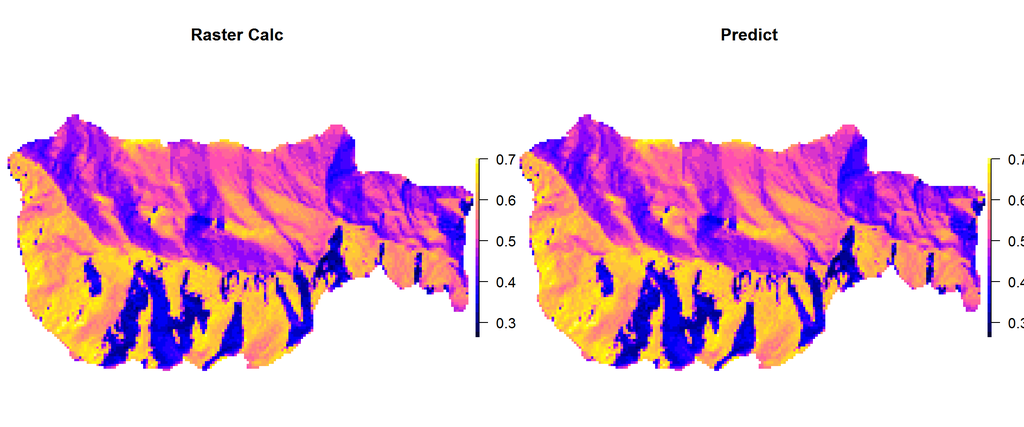

## Abundance

Let’s use the same point count data to determine how many Ovenbirds are breeding within Hubbard Brook. We first need to create another unmarked frame for the abundance model. We will use the `pcount` function to estimate abundance.

We need to use the data we collated earlier - not the binary data we used for occupancy.

```r
str(spec.mat_OVEN)
```

```
##  num [1:373, 1:3, 1:4] 0 0 0 0 0 0 1 0 0 1 ...
##  - attr(*, "dimnames")=List of 3
##   ..$ : chr [1:373] "1" "2" "3" "4" ...
##   ..$ : NULL
##   ..$ : NULL
```

```r
# Make an empty list to store the unmarked frames in.
# We first specify the abundance data, y=spec.mat_OVEN[,,replicate]
# we then set the siteCovs as our siteCovs matrix

OVEN<-vector('list',4)
for(i in 1:4){
OVEN[[i]]<-unmarkedFramePCount(y=spec.mat_OVEN[,,i],
                               siteCovs=siteCovs)
}
```

**Run the analysis**

*note* - formula format - ~covariates of detection ~ covariates for abundance in that order

```r
# formula describing covariates of detection and abundance, in that order
Abun0<-pcount(~1 ~Elevation + Aspect + Slope, OVEN[[1]], K=200, mixture=c("P"),
              method="BFGS", se=TRUE, engine="C")
```

```r
# compute the expected abundance at each grid cell
# sum(lamnew) is the expected value of total population size

## extract the coefficients for the best model
betaAbun0<-coef(Abun0)
```

#### Exercise:

> Prior to N-mixture models, people used the maximum number of individuals within a count to determine abundance.

> Compare the population size of Ovenbirds that was sampled:
> 1. without accounting for imperfect detection
> 2. after accounting for imperfect detection

> What do you expect to find? Why?

```r
# This function first finds the maximum number of Ovenbirds per count (rows), then sums them to get a raw abundance value.

sum(apply(spec.mat_OVEN[,,1],1,max))
```

```
## [1] 233
```

```r
# This the predict function run applies the model results to a set of data - here our site covariates. We then sum the first column of the output which is the abundance estimate.

sum(predict(Abun0,type="state",newdata=siteCovs,appendData=FALSE)[,1])
```

```
## [1] 255.4618
```

Now, let’s make predictions for the entire Hubbard Brook valley.

```r
# Raster calculation

Abundance0<-overlay(elevation,aspect,slope,fun=function(x,y,z){
                  exp(betaAbun0[1]+ # intercept
                      betaAbun0[2]*x +  # x is the elevation layer
                      betaAbun0[3]*y +  # y is the aspect layer
                      betaAbun0[4]*z)})   # z in the slope layer
```

Here is another way to make predictions without using the raster package.

```r
AbunPred<-predict(Abun0,type="state",newdata=NewData,appendData=TRUE)
```

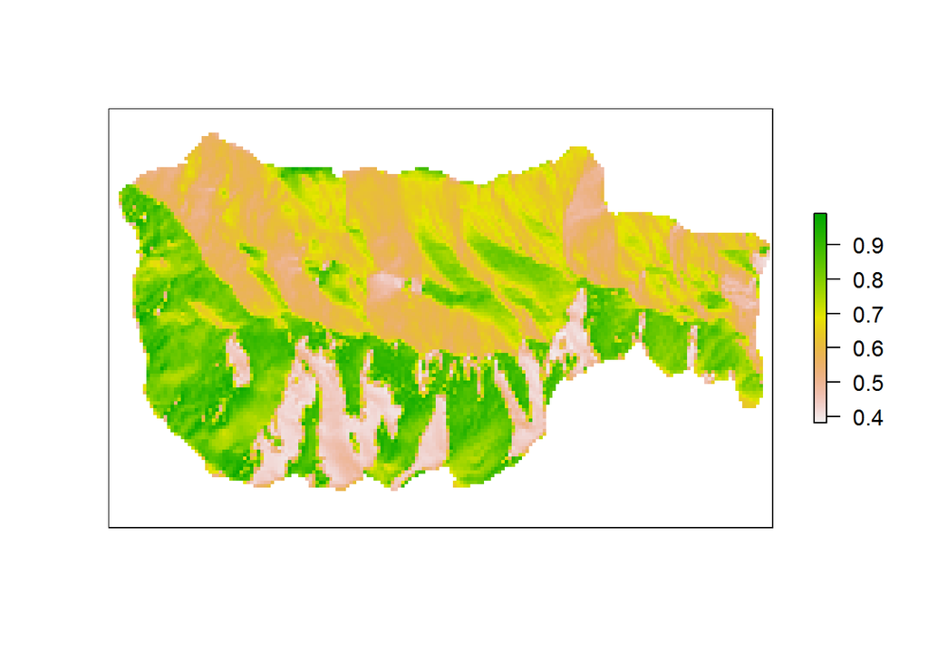

```r
# Make a raster of Ovenbird abundance #
Abun0<-rasterFromXYZ(cbind(AbunPred[,5:6],AbunPred[,1]))

# Cut to just HBEF #
Abun0<-mask(Abun0,HBEF)

plot(Abun0,axes=FALSE)
```

```r
# How many Ovenbirds are there within HBEF #
cellStats(Abun0,sum)
```

```
## [1] 9253.733
```

## Advanced example

### Analysis in a Bayesian framework

*note* additional software is required program JAGS or OpenBUGS.

The subsequent code is for doing the same analysis but in a Bayesian framework. This approach is a bit more flexible. It allows us to use the abundance during the previous count to inform the subsequent count.

Specifying the model

```r
#library(abind)
#library(R2jags)

#########################################################################################
#########################################################################################
#
#         MODEL
#
#########################################################################################
#########################################################################################

Settlment.dm.bayes.model<-function()
{
##########################################################################################
#
#  Priors

##########################################################################################
   gam0 ~ dnorm(0, 0.01)  # intercept for t+1
   gam1 ~ dnorm(0, 0.01)  # recruitment parameter
   pInt ~ dnorm(0, 0.01)  # intercept for detection
   alpha ~ dnorm(0,0.01)  # intercept for first count


# beta estimates
   for (c in 1:ncovs){
       beta[c]~dnorm(mu.theta,tau.theta)
       betaG[c]~dnorm(mu.theta,tau.theta)
      } #ncovs

# detection
for (m in 1:pcovs){
      betaP[m]~dnorm(mu.thetaP,tau.thetaP)
  } #pcovs
for(k in 1:nreplicate){
Error[k]~dnorm(0,0.01)
}    #nyears

### Hyperpriors #######
mu.theta ~ dnorm(0,0.01)
tau.theta ~ dgamma(0.001,0.001)
mu.thetaP ~ dnorm(0,0.01)
tau.thetaP ~ dgamma(0.001,0.001)

##########################################################################################
#
#  Likelihood
#
##########################################################################################
for(i in 1:nschwarz) {                       # Schwarz Plot
     N[i,1] ~ dpois(lambda[i,1])
     lambda[i,1]<-exp( alpha+               #intercept
                       beta[1]*Elev[i]+        #Elevation
                       beta[2]*Slope[i]+       #Slope
                       beta[3]*Aspect[i]+      #Aspect
                       Error[1])             #Random Error term

   for(j in 1:nperiod) {                        # Periods within Count
     y[i,j,1] ~ dbin(p[i,j,1], N[i,1])
     p[i,j,1]<-1/(1+exp(-logit.p[i,j,1]))
     logit.p[i,j,1]<-pInt+                     # Detection intercept
                     betaP[1]*time[i,1]+     # time of count
                     betaP[2]*date[i,1]+     # date of count
                     betaP[3]*obsvr[i,1]     # observer who counted
     } #Period

for(k in 2:nreplicate) {                      # Replicates
     N[i,k] ~ dpois(gamma[i,k-1])
     gamma[i,k-1] <- exp(gam0+                # intercept
                         gam1*N[i,k-1]+       # Recruitment
             betaG[1]*Elev[i]+
                         betaG[2]*Slope[i]+
                         betaG[3]*Aspect[i]+
                         Error[k])

     for(j in 1:nperiod){                      # Periods within Count
     y[i,j,k] ~ dbin(p[i,j,k], N[i,k])
     p[i,j,k]<-1/(1+exp(-logit.p[i,j,k]))
     logit.p[i,j,k]<-pInt+
                     betaP[1]*time[i,k]+
                     betaP[2]*date[i,k]+
                     betaP[3]*obsvr[i,k]
     }    # Period
   }      # Replicate
} # Schwarz
################################################################
#
# Derived parameters
#
################################################################
#
# Calculate the population size sampled at HBEF in each replicate, k.
#
for(k in 1:nreplicate) {
  Ntot[k] <- sum(N[,k])
  }
 P <- mean(p[,,])

} # END MODEL
```

We need to give JAGS (the Gibbs Sampler) the starting values for the analysis - these are called the initial values.

```r
# Set initial values for N
#

# create array with same dimensions as abundance estimates

# Set up data to run in parallel #

nreplicate<-4
ncovs<-3
nschwarz<-373
nperiod<-3
pcovs<-3

y<-spec.mat_OVEN

Elev<-siteCovs[,1]
Aspect<-siteCovs[,2]
Slope<-siteCovs[,3]

date<-doy.15scaled
obsvr<-obs.15
time<-time

win.data<-list("y", "nschwarz", "nreplicate", "nperiod",
              "ncovs","pcovs","Elev", "time", "date", "obsvr",
              "Slope","Aspect")

# Function to put into initial values for Nst #
N<-function(x){
Nst<-array(NA,dim=c(nschwarz,nreplicate))
Nst<-apply(x,c(1,3),max,na.rm=TRUE)+3
# If Nst==NA change value to 3 #
Nst[Nst==-Inf]<-NA
Nst[is.na(Nst)]<-3
return(Nst)
}

# setting the seed makes it so the results are the same every time
# it makes it so the random number generator generates the same
# numbers every time
set.seed(04823)
inits<-function() list(gam0=rnorm(1,0.01),  # sample 1 random number from a normal dist.
                       gam1=rnorm(1,0.01),  # sample 1 random number from a normal dist.
                       mu.theta=0,
                       tau.theta=10,
                       mu.thetaP=0,
                       tau.thetaP=10,
                       N=N(y))

# Set the number of chains to run
nchains<-3

inits.parallel<-list()
for(i in 1:nchains){
inits.parallel[[i]]<-inits()
}

# Specify wihch parameters you want to monitor
params<-c("N","Ntot","alpha","beta","betaG","betaP","Error","P","gam0","gam1")

set.seed(04823)

# read in code that allows for parallel computation
source("source/sourceJAGS.parallel2.r")

Sys.time()
```

```
## [1] "2015-09-24 11:40:32 EDT"
```

```r
dm.fit.settlement<-jags.parallel2(model=Settlment.dm.bayes.model,
                                  data=win.data,
                                  inits=inits.parallel,
                                  parameters=params,
                                  jags.seed=04823,
                                  n.iter=10000,
                                    n.burnin=5000,
                                  n.thin=25,
                                  n.chains=3,
                                  working.directory=getwd())
```

```
## Started
## Made clusters
## Exported clusters
## Set random numbers
## Ran JAGS
## Combined results
```

```r
Sys.time()
```

```
## [1] "2015-09-24 11:45:01 EDT"
```

Get mean estimates of the following variables so we can make predictions

```r
beta<-dm.fit.settlement$BUGSoutput$mean$beta
betaG<-dm.fit.settlement$BUGSoutput$mean$betaG
Alpha<-dm.fit.settlement$BUGSoutput$mean$alpha
Error<-dm.fit.settlement$BUGSoutput$mean$Error
gam0<-dm.fit.settlement$BUGSoutput$mean$gam0
gam1<-dm.fit.settlement$BUGSoutput$mean$gam1

# Map predictions from JAGS model

# Make the prediction surfaces

Elev_pred<-rasterFromXYZ(NewData[,1:3])
Slope_pred<-rasterFromXYZ(NewData[,c(1:2,5)])
Aspect_pred<-rasterFromXYZ(NewData[,c(1:2,4)])
```

**Making predictions**

```r
# Use the equation in the model to make predictions of round 0 #
Round0<-overlay(Elev_pred,Aspect_pred,Slope_pred,fun=function(x,y,z){
               exp(Alpha+beta[1]*x+beta[2]*z+beta[3]*y+Error[1])})

# Include previous rounds Abundance estimate into model - NOTE (Round0) #
Round1<-overlay(Elev_pred,Aspect_pred,Slope_pred,Round0,fun=function(x,y,z,a){
               exp(gam0+gam1*a+betaG[1]*x+betaG[2]*z+betaG[3]*y+Error[2])})

# Include previous rounds Abundance estimate into model - NOTE (Round1) #
Round2<-overlay(Elev_pred,Aspect_pred,Slope_pred,Round1,fun=function(x,y,z,a){
               exp(gam0+gam1*a+betaG[1]*x+betaG[2]*z+betaG[3]*y+Error[3])})

# Include previous rounds Abundance estimate into model - NOTE (Round2) #
Round3<-overlay(Elev_pred,Aspect_pred,Slope_pred,Round2,fun=function(x,y,z,a){
               exp(gam0+gam1*a+betaG[1]*x+betaG[2]*z+betaG[3]*y+Error[4])})

# Cut the estimates to only HBEF #
Round0<-mask(Round0,HBEF)
Round1<-mask(Round1,HBEF)
Round2<-mask(Round2,HBEF)
Round3<-mask(Round3,HBEF)
```

**Calculate the change in abundance between the rounds**

```r
diff0_1<-overlay(Round0,Round1,fun=function(x,y){y-x})
diff1_2<-overlay(Round1,Round2,fun=function(x,y){y-x})
diff2_3<-overlay(Round2,Round3,fun=function(x,y){y-x})
diff0_3<-overlay(Round0,Round3,fun=function(x,y){y-x})


# Calculate the number of OVENBIRDS #
cellStats(Round0,sum)
```

```
## [1] 8787.013
```

```r
cellStats(Round1,sum)
```

```
## [1] 10484.23
```

```r
cellStats(Round2,sum)
```

```
## [1] 8264.904
```

```r
cellStats(Round3,sum)
```

```
## [1] 8678.428
```

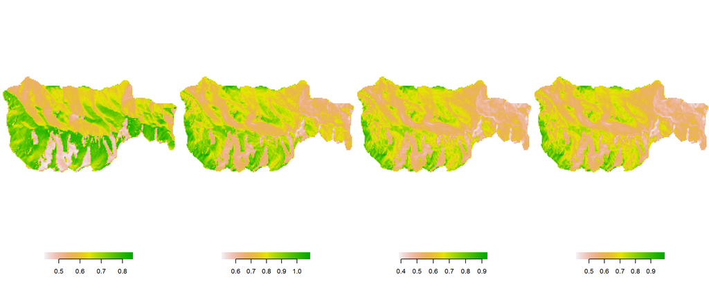